# Lab 10 Replication

Christopher Prener, Ph.D.

(November 12, 2018)

## Introduction

This notebook replicates lab-10.

## Dependencies

This notebook requires the following packages:

```r
# tidyverse packages
library(dplyr)
library(ggplot2)
library(readr)

# other packages
library(ggstatsplot)
library(here)
library(knitr)
library(naniar)
library(pwr)
library(testDriveR)
```

We also use the following custom function for creating correlation tables:

```r
source(here("source", "corrTable.R"))
```

## Data

We’ll assign the data for the lab to a new object named `autoData`.

```r
autoData <- auto17
```

## Part 1: Data Preparation

### Questions 1 and 2

First, we’ll create the guzzler binary variable and subset our data.

```r
autoData %>%
  mutate(guzzlerBin = ifelse(guzzlerStr == "G", TRUE, FALSE)) %>%
  select(id, combFE, fuelCost, cyl, guzzlerBin) -> autoSub
```

We also want to write these to the `data/` folder since they will be our analytic sample:

```r
write_csv(autoSub, here("data", "autoAnalysis.csv"))
```

### Question 3

We want to check for missing data in the analytic sample. We can use `naniar` for this task.

```r
autoSub %>%
  miss_var_summary() %>%
  kable()
```

[output not shown]

We do not have any missing data concerns with our analytic sample.

## Part 2: Creating Scatterplots

### Question 4

The following code produces a scatterplot between the variables `combFE` and `fuelCost`.

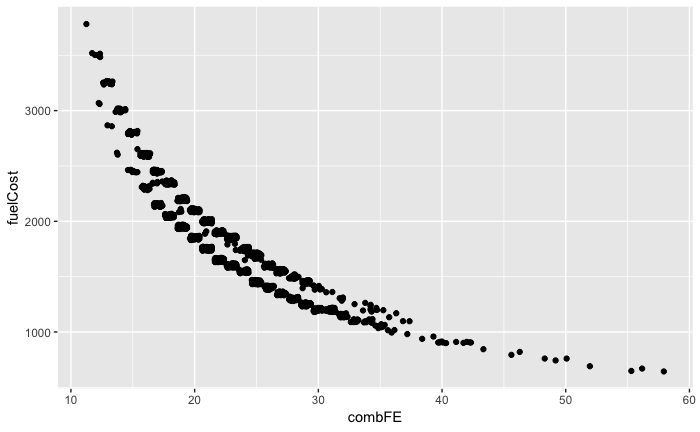

```r
plot <- ggplot(data = autoData) +
  geom_point(mapping = aes(x = combFE, y = fuelCost), position = "jitter")

ggsave(here("results", "p2_q4_plot.png"), plot, dpi = 300)
plot
```

We can see a clear, if non-linear, relationship between the two variables, which is a concern for the assumptions related to Pearson’s $r$. As fuel efficiency increases, the cost of fuel declines.

### Question 5

We can use the new guzzler variable to color the points of our scatterplot.

```r
plot <- ggplot(data = autoSub) +
  geom_point(mapping = aes(x = combFE, y = fuelCost, color = guzzlerBin), position = "jitter")

ggsave(here("results", "p2_q5_plot.png"), plot, dpi = 300)

plot
```

[output not shown]

This plot shows that all of the guzzler vehicles have both high fuel cost and lost fuel efficiency.

### Question 6

Next, we’ll facet the data so that the guzzler vehicles are in one panel and the non-guzzler vehicles are in another.

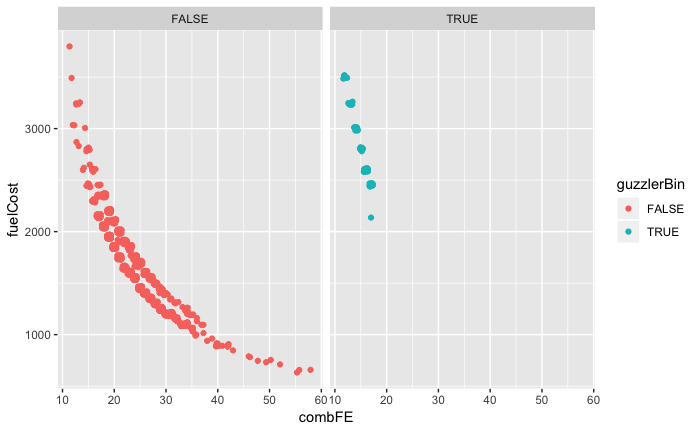

```r
ggplot(data = autoSub) +
  geom_point(mapping = aes(x = combFE, y = fuelCost, color = guzzlerBin), position = "jitter") +
  facet_wrap(. ~ guzzlerBin)
```

This helps us isolate the difference in pattern between guzzler and non-guzzler vehicles.

### Question 7

We’ll go ahead and add lines for linear models as well:

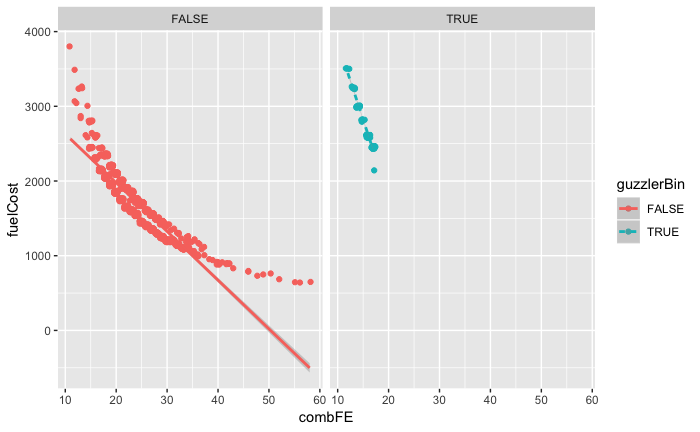

```r
plot <- ggplot(data = autoSub, mapping = aes(x = combFE, y = fuelCost, color = guzzlerBin)) +
  geom_point(position = "jitter") +
  geom_smooth(method = "lm", mapping = aes(linetype = guzzlerBin)) +
  facet_wrap(. ~ guzzlerBin)

ggsave(here("results", "p2_q7_plot.png"), plot, dpi = 300)
plot
```

We can see how poor of a fit the linear model is for the non-guzzler data in this plot. A linaer relationship should absolutely not be assumed to exist here!

### Question 8

*Skipped*

## Part 3: Correlation in `R`

### Question 9

```r
autoSub %>%
  corrTable(coef = "pearson", listwise = TRUE, round = 3, pStar = TRUE, combFE, fuelCost, cyl, guzzlerBin) %>%
  kable()
```

|  | combFE | fuelCost | cyl | guzzlerBin |
| --- | --- | --- | --- | --- |
| combFE | 1.000 |  |  |  |
| fuelCost | -0.899*** | 1.000 |  |  |
| cyl | -0.723*** | 0.843*** | 1.000 |  |
| guzzlerBin | -0.340*** | 0.516*** | 0.576*** | 1.000 |

We can also pipe this into a `.csv` file for later reference:

```r
autoSub %>%
  corrTable(coef = "pearson", listwise = TRUE, round = 3, pStar = TRUE, combFE, fuelCost, cyl) %>%
  write_csv(here("results", "corr.csv"))
```

### Question 10

There is a strong, negative relationship between combined fuel efficiency and fuel cost ($r = -.899, p < .001$). The higher the fuel cost, the lower the fuel efficiency of the vehicle.

### Question 11

There is a strong, positive relationship between fuel cost and number of cylinders ($r = .843, p < .001$). The higher the number of cylinders in the engine, the higher the fuel cost of the vehicle.

### Question 12

There is a strong, negative relationship between combined fuel efficiency and number of cylinders ($r = -.723, p < .001$). The higher the number of cylinders in the engine, the lower the fuel efficiency of the vehicle.

## Part 4: Sample Size Estimates

## Question 13

The following code calculates an estimated sample size for the given parameters.

```r
pwr.r.test(r = .89, sig.level = .05, power = .8, alternative = "two.sided")
```

[output not shown]

We would need a sample of at least 7 people (in reality, 30) to see this effect size ($r=.89$) at the given level of power ($power = .8$)

## Question 14

The following code calculates an estimated sample size for the given parameters.

```r
pwr.r.test(r = .29, sig.level = .05, power = .9, alternative = "two.sided")
```

[output not shown]

We would need a sample of at least 120 people to see this effect size ($r=.29$) at the given level of power ($power = .9$)